# BryanNonni_MLA1_Final

## Introduction to Machine Learning: Assignment 1

### Due: September 30, 2019

**1. Maximum Posteriori Hypothesis (10 points)**

When a test for steroids is given to soccer players, 98% of the players taking steroids test positive and 12% of the players not taking steroids test positive. Suppose that 5% of soccer players take steroids. What is the maximum posteriori hypothesis for a soccer player who tests positive? What are the exact posterior probabilities?

**Max Posteriori Formula ($h_{MAP}$)**

$h_{MAP} = arg\,max_{h_i \in H} P(D|h)P(h)$

$h = steroids | \neg steroids$

$D = + | -$

**Given:** $P(steroids) = 0.05, \, P(\neg steroids) = 0.95$

**Q: What are the exact posterior probabilities?**

$P(+|\neg steroids) = 0.12 \; (false\;positive), \; P(-|\neg steroids) = 0.88 \; (true\;positive)$

$P(+|steroids) = 0.98 \; (true\,positive), \, P(-|steroids) = 0.02 \; (false\,negative)$

**Q: What is the maximum posteriori hypothesis for a soccer player who tests positive?**

$P(+|steroids)*P(steroids) = (0.98)(0.05) = 0.049 \approx 5\%$

$P(+|\neg steroids)*P(\neg steroids) = (0.12)(0.95) = 0.114 \approx 11\%$

$h_{MAP} = arg\,max_{h_i \in H} \{5\%, 11\%\}$

$\implies 11\% > 5\%$

$\therefore \, h_{MAP} = \neg steroids$

**2. Naive Bayes Classifier (20 Points + 10 Points)**

**2.1** Consider the hypothesis space defined over these instances (Table 1), in which each hypothesis is represented by a pair of 4-tuples. Using the native Bayes classifier to predict the target value PlayTennis = Yes/No to the following instance.

Table 1: Training examples for the target concept PlayTennis

| Day | Outlook | Temperature | Humidity | Wind | Play |
| --- | --- | --- | --- | --- | --- |
| D1 | Sunny | Hot | Normal | Weak | No |
| D2 | Sunny | Hot | High | Strong | No |
| D3 | Overcast | Hot | High | Weak | Yes |
| D4 | Rain | Mild | Normal | Strong | Yes |
| D5 | Rain | Cool | Normal | Weak | Yes |
| D6 | Rain | Mild | Normal | Strong | No |
| D7 | Overcast | Cool | Normal | Strong | Yes |
| D8 | Rain | Mild | High | Weak | No |
| D9 | Sunny | Cool | Normal | Strong | Yes |
| D10 | Rain | Hot | Normal | Strong | Yes |
| D11 | Sunny | Mild | Normal | Strong | Yes |
| D12 | Sunny | Mild | Normal | Weak | No |
| D13 | Overcast | Hot | Normal | Weak | Yes |
| D14 | Sunny | Cool | High | Weak | No |

**Naive Bayes Classifier [$P(c|x)$]**

$P(c|x) = \frac{P(x|c)P(c)}{P(x)}\, = \, P(x_1|c) \, \cdot P(x_2|c) \, \cdot \, ... \, \cdot \, P(x_n|c) \, \cdot \, P(c)$

**Given:**

$c = Play|\neg Play$

$x_a =\, < Sunny, Mild, Normal, Weak >$

$x_b =\, < Rain, Cool, High, Strong >$

**a)** $x_a =\, < Sunny, Mild, Normal, Weak >$

$P(c|x_a) = (Play \,| <Sunny, Mild, Normal, Weak>)$

$P(Play|x_{a,i}) = P(Sunny|Play) \,\cdot\, P(Mild|Play) \,\cdot\, P(Normal|Play) \,\cdot\, P(Weak|Play) \,\cdot\, P(Play)$

$= \frac{1}{4} \,\cdot\, \frac{1}{4} \,\cdot\, \frac{7}{8} \,\cdot\, \frac{3}{8} \,\cdot\, \frac{4}{7}$

$= 0.25 \,\cdot\, 0.25 \,\cdot\, 0.875 \,\cdot\, 0.375 \,\cdot\, 0.571 \, = 0.01171 \approx 1.17\%$

$=\frac{0.01171}{0.01171 + 0.0475} = \frac{0.01171}{0.0592} = 0.1978 \approx 19.8\%$

$(\neg Play \,| <Sunny, Mild, Normal, Weak>)$

$P(\neg Play|x_{a,i}) = P(Sunny|\neg Play) \,\cdot\, P(Mild|\neg Play) \,\cdot\, P(Normal|\neg Play) \,\cdot\, P(Weak|\neg Play) \,\cdot\, P(\neg Play)$

$= \frac{2}{3} \,\cdot\, \frac{1}{2} \,\cdot\, \frac{1}{2} \,\cdot\, \frac{2}{3} \,\cdot\, \frac{3}{7}$

$= 0.667 \,\cdot\, 0.5 \,\cdot\, 0.5 \,\cdot\, 0.667 \,\cdot\, 0.428 \, = 0.0475 \approx 4.76\%$

$=\frac{0.0475}{0.01171 + 0.0475} = \frac{0.0475}{0.0592} = 0.8023 \approx 80.2\%$

$80.2\% > 19.8\%$

$\therefore x_a = \neg Play$

**b)** $x_b =\, <Rain, Cool, High, Strong >$

$P(c|x_b) = (Play \,| <Rain, Cool, High, Strong>)$

$P(Play|x_{b,i}) = P(Rain|Play) \,\cdot\, P(Cool|Play) \,\cdot\, P(High|Play) \,\cdot\, P(Strong|Play) \,\cdot\, P(Play)$

$= \frac{3}{8} \,\cdot\, \frac{3}{8} \,\cdot\, \frac{1}{8} \,\cdot\, \frac{5}{8} \,\cdot\, \frac{4}{7}$

$= 0.375 \,\cdot\, 0.375 \,\cdot\, 0.125 \,\cdot\, 0.625 \,\cdot\, 0.571 \, = 0.00627 \approx 0.63\%$

$=\frac{0.00627}{0.00627 + 0.00396} = \frac{0.00627}{0.01023} = 0.6129 \approx 61.3\%$

$(\neg Play \,| <Rain, Cool, High, Strong>)$

$P(\neg Play|x_{a,i}) = P(Rain|\neg Play) \,\cdot\, P(Cool|\neg Play) \,\cdot\, P(High|\neg Play) \,\cdot\, P(Strong|\neg Play) \,\cdot\, P(\neg Play)$

$= \frac{1}{3} \,\cdot\, \frac{1}{6} \,\cdot\, \frac{1}{2} \,\cdot\, \frac{1}{3} \,\cdot\, \frac{3}{7}$

$= 0.333 \,\cdot\, 0.1667 \,\cdot\, 0.5 \,\cdot\, 0.333 \,\cdot\, 0.428 \, = 0.00396 \approx 0.40\%$

$=\frac{0.00396}{0.00627 + 0.00396} = \frac{0.00396}{0.01023} = 0.3871 \approx 38.7\%$

$61.2\% > 38.7\%$

$\therefore x_b = Play$

**2.2** Consider the following example and calculate the accuracy of the classifier with precision, recall, F1-score, sensitivity, specificity and ROC curve using Python.

```python
import os
import pandas as pd
import numpy as np
import matplotlib.pyplot as plt

from sklearn.naive_bayes import GaussianNB, BernoulliNB
from sklearn.linear_model import LogisticRegression
from sklearn.model_selection import train_test_split, GridSearchCV
from sklearn.metrics import confusion_matrix, auc, roc_curve, roc_auc_score, classification_report
from sklearn.metrics import recall_score, precision_score, accuracy_score, f1_score

%matplotlib inline


df_A = pd.DataFrame(pd.read_csv('data/Table1/table1.csv'))
df_A.keys()
```

```
Index(['Day', 'Outlook', 'Temperature', 'Humidity', 'Wind', 'Play'], dtype='object')
```

```python
def make_label(p):
    if p == 'Yes':
        return 1
    else:
        return 0
```

## Naive Bayes Vector A

```python
df_A['Play_Label'] = df_A['Play'].apply(make_label)
df_A.head()
```

|  | Day | Outlook | Temperature | Humidity | Wind | Play | Play_Label |
| --- | --- | --- | --- | --- | --- | --- | --- |
| 0 | D1 | Sunny | Hot | Normal | Weak | No | 0 |
| 1 | D2 | Sunny | Hot | High | Strong | No | 0 |
| 2 | D3 | Overcast | Hot | High | Weak | Yes | 1 |
| 3 | D4 | Rain | Mild | Normal | Strong | Yes | 1 |
| 4 | D5 | Rain | Cool | Normal | Weak | Yes | 1 |

```python
df_A['Outlook_Label'] = df_A['Outlook'].str.contains('Sunny')
df_A['Temperature_Label'] = df_A['Temperature'].str.contains('Mild')
df_A['Humidity_Label'] = df_A['Humidity'].str.contains('Normal')
df_A['Wind_Label'] = df_A['Wind'].str.contains('Weak')
df_A.head()
```

|  | Day | Outlook | Temperature | Humidity | Wind | Play | Play_Label | Outlook_Label | Temperature_Label | Humidity_Label | Wind_Label |
| --- | --- | --- | --- | --- | --- | --- | --- | --- | --- | --- | --- |
| 0 | D1 | Sunny | Hot | Normal | Weak | No | 0 | True | False | True | True |
| 1 | D2 | Sunny | Hot | High | Strong | No | 0 | True | False | False | False |
| 2 | D3 | Overcast | Hot | High | Weak | Yes | 1 | False | False | False | True |
| 3 | D4 | Rain | Mild | Normal | Strong | Yes | 1 | False | True | True | False |
| 4 | D5 | Rain | Cool | Normal | Weak | Yes | 1 | False | False | True | True |

```python
df_A[['Outlook_Label', 'Temperature_Label', 'Humidity_Label','Wind_Label']].head()
```

|  | Outlook_Label | Temperature_Label | Humidity_Label | Wind_Label |
| --- | --- | --- | --- | --- |
| 0 | True | False | True | True |
| 1 | True | False | False | False |
| 2 | False | False | False | True |
| 3 | False | True | True | False |
| 4 | False | False | True | True |

```python
X_A = df_A[['Outlook_Label', 'Temperature_Label', 'Humidity_Label', 'Wind_Label']]
y_A = df_A['Play_Label']
```

# Gaussian NB

## Train_Test_Split = 50/50 Test/Train

```python
X_A_train, X_A_test, y_A_train, y_A_test = train_test_split(X_A, y_A, test_size=0.5, random_state=1)
```

```python
GNB.fit(X_A_train, y_A_train)
y_A_pred = GNB.predict(X_A_test)
GNB.score(X_A_test, y_A_test)
```

```
0.5714285714285714
```

```python
confusion_matrix(y_A_test, y_A_pred)
```

```
array([[2, 0],
       [3, 2]])
```

```python
pd.crosstab(y_A_test, y_A_pred, rownames=['Play'], colnames=['Predicted'], margins=True)
```

| Predicted Play | 0 | 1 | All |
| --- | --- | --- | --- |
| 0 | 2 | 0 | 2 |
| 1 | 3 | 2 | 5 |
| All | 5 | 2 | 7 |

```python
print(classification_report(y_A_test, y_A_pred))
```

```
              precision    recall  f1-score   support

           0       0.40      1.00      0.57         2
           1       1.00      0.40      0.57         5

   micro avg       0.57      0.57      0.57         7
   macro avg       0.70      0.70      0.57         7
weighted avg       0.83      0.57      0.57         7
```

```python
y_A_pred_proba = GNB.predict_proba(X_A_test)[:,1]
```

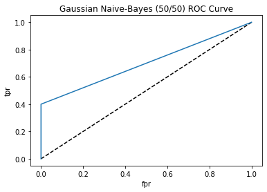

```python
fpr, tpr, thresholds = roc_curve(y_A_test, y_A_pred_proba)
plt.plot([0,1],[0,1], 'k--')
plt.plot(fpr, tpr, label='GNB')
plt.xlabel('fpr')
plt.ylabel('tpr')
plt.title('Gaussian Naive-Bayes (50/50) ROC Curve')
plt.show()
```

```python
roc_auc_score(y_A_test, y_A_pred_proba)
```

```
0.7
```

## Naive Bayes Vector B

```python
df_B = pd.DataFrame(pd.read_csv('data/Table1/table1.csv'))
df_B['Play_Label'] = df_B['Play'].apply(make_label)
df_B.head()
```

|  | Day | Outlook | Temperature | Humidity | Wind | Play | Play_Label |
| --- | --- | --- | --- | --- | --- | --- | --- |
| 0 | D1 | Sunny | Hot | Normal | Weak | No | 0 |
| 1 | D2 | Sunny | Hot | High | Strong | No | 0 |
| 2 | D3 | Overcast | Hot | High | Weak | Yes | 1 |
| 3 | D4 | Rain | Mild | Normal | Strong | Yes | 1 |
| 4 | D5 | Rain | Cool | Normal | Weak | Yes | 1 |

```python
df_B['Outlook_Label'] = df_B['Outlook'].str.contains('Rain')
df_B['Temperature_Label'] = df_B['Temperature'].str.contains('Cool')
df_B['Humidity_Label'] = df_B['Humidity'].str.contains('High')
df_B['Wind_Label'] = df_B['Wind'].str.contains('Strong')
df_B.head()
```

|  | Day | Outlook | Temperature | Humidity | Wind | Play | Play_Label | Outlook_Label | Temperature_Label | Humidity_Label | Wind_Label |
| --- | --- | --- | --- | --- | --- | --- | --- | --- | --- | --- | --- |
| 0 | D1 | Sunny | Hot | Normal | Weak | No | 0 | False | False | False | False |
| 1 | D2 | Sunny | Hot | High | Strong | No | 0 | False | False | True | True |
| 2 | D3 | Overcast | Hot | High | Weak | Yes | 1 | False | False | True | False |
| 3 | D4 | Rain | Mild | Normal | Strong | Yes | 1 | True | False | False | True |
| 4 | D5 | Rain | Cool | Normal | Weak | Yes | 1 | True | True | False | False |

```python
df_B[['Outlook_Label', 'Temperature_Label', 'Humidity_Label','Wind_Label']].head()
```

|  | Outlook_Label | Temperature_Label | Humidity_Label | Wind_Label |
| --- | --- | --- | --- | --- |
| 0 | False | False | False | False |
| 1 | False | False | True | True |
| 2 | False | False | True | False |
| 3 | True | False | False | True |
| 4 | True | True | False | False |

```python
X_B = df_B[['Outlook_Label', 'Temperature_Label', 'Humidity_Label', 'Wind_Label']]
y_B = df_B['Play_Label']
```

# Gaussian NB

## Train_Test_Split = 50/50 Train/Test

```python
X_B_train, X_B_test, y_B_train, y_B_test = train_test_split(X_B, y_B, test_size=0.5, random_state=1)
GNB.fit(X_B_train, y_B_train)
y_B_pred = GNB.predict(X_B_test)
GNB.score(X_B_test, y_B_test)
```

```
0.8571428571428571
```

```python
pd.crosstab(y_B_test, y_B_pred, rownames=['actual'], colnames=['Predicted'], margins=True)
```

| Predicted actual | 0 | 1 | All |
| --- | --- | --- | --- |
| 0 | 2 | 0 | 2 |
| 1 | 1 | 4 | 5 |
| All | 3 | 4 | 7 |

```python
print(classification_report(y_B_test, y_B_pred))
```

```
              precision    recall  f1-score   support

           0       0.67      1.00      0.80         2
           1       1.00      0.80      0.89         5

   micro avg       0.86      0.86      0.86         7
   macro avg       0.83      0.90      0.84         7
weighted avg       0.90      0.86      0.86         7
```

```python
y_B_pred_proba = GNB.predict_proba(X_B_test)[:,1]
```

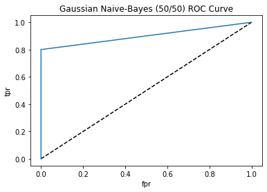

```python
fpr, tpr, thresholds = roc_curve(y_B_test, y_B_pred_proba)
plt.plot([0,1],[0,1], 'k--')
plt.plot(fpr, tpr, label='GNB')
plt.xlabel('fpr')
plt.ylabel('tpr')
plt.title('Gaussian Naive-Bayes (50/50) ROC Curve')
plt.show()
```

```python
roc_auc_score(y_B_test, y_B_pred_proba)
```

```
0.9
```

**3. KNN (20 Points + 10 Points)**

**3.1** Table 2 is a gene expression microarray data, where each row represents a sample for a person, each column represents a gene, and each entry represents gene expression value of a gene over a sample. The output of each sample indicates whether a specific disease exists in this sample. Please use Euclidean DistanceWeighted KNN (K=3) to predict the output of the sample 11 and sample 12.

| Sample | G1 | G2 | G3 | G4 | G5 | G6 | G7 | Output |
| --- | --- | --- | --- | --- | --- | --- | --- | --- |
| 1 | 1.0 | 2.3 | 5.2 | 1.2 | 5.3 | 2.6 | 2.3 | Yes |
| 2 | 2.0 | 3.6 | 1.8 | 2.3 | 1.6 | 2.1 | 1.5 | No |
| 3 | 1.5 | 1.5 | 4.1 | 1.3 | 1.2 | 3.1 | 1.6 | Yes |
| 4 | 2.2 | 1.9 | 9.5 | 1.5 | 1.5 | 4.2 | 1.4 | No |
| 5 | 3.9 | 2.4 | 5.3 | 1.7 | 1.6 | 2.5 | 2.9 | Yes |
| 6 | 5.1 | 3.6 | 2.7 | 2.6 | 1.7 | 2.8 | 3.4 | Yes |
| 7 | 1.8 | 4.2 | 3.6 | 3.5 | 1.6 | 3.4 | 1.3 | No |
| 8 | 2.3 | 1.5 | 7.2 | 4.1 | 7.1 | 3.1 | 1.8 | No |
| 9 | 4.2 | 2.4 | 6.2 | 2.9 | 2.5 | 3.3 | 2.5 | Yes |
| 10 | 3.6 | 5.6 | 1.9 | 3.2 | 2.6 | 5.2 | 2.7 | No |

Table 2: Gene expression data

**Euclidean Distance [$D(x,y)$]**

$D(x,y) = \sqrt{(x_1 - y_1)^2 + (x_2 - y_2)^2\,+\,...\,+ (x_n - y_n)^2}$

**Given**

$x = sample_{1-10} <G1, G2, G3, G4, G5, G6, G7>$

$y = sample_{12} <2.4, 2.3, 3.4, 3.8, 2.3, 5.7, 5.2>$

**KNN Distance ($K$)**

$K = 3$

$D(1,11) = \sqrt{(<1,G1> -<11,G1>)^2 + (<1,G2> - <11,G2>)^2 + ... + (<1,G7> - <11,G7>)^2} = 2.489 \approx 2.49$

$D(2,11) = \sqrt{(<2,G1> - <11,G1>)^2 + (<2,G2> - <11,G2>)^2 + ... + (<2,G7> - <11,G7>)^2} = 4.134 \approx 4.13$

$D(3,11) = \sqrt{(<3,G1> - <11,G1>)^2 + (<3,G2> - <11,G2>)^2 +... + (<3,G7> - <11,G7>)^2} = 4.173 \approx 4.17$

$D(4,11) = \sqrt{(<4,G1> - <11,G1>)^2 + (<4,G2> - <11,G2>)^2 + ... + (<4,G7> - <11,G7>)^2} = 7.483 \approx 7.48$

$D(5,11) = \sqrt{(<5,G1> - <11,G1>)^2 + (<5,G2> - <11,G2>)^2 + ... + (<5,G7> - <11,G7>)^2} = 4.721 \approx 4.72$

$D(6,11) = \sqrt{(<6,G1> - <11,G1>)^2 + (<6,G2> - <11,G2>)^2 + ... + (<6,G7> - <11,G7>)^2} = 5.326 \approx 5.33$

$D(7,11) = \sqrt{(<7,G1> - <11,G1>)^2 + (<7,G2> - <11,G2>)^2 + ... + (<7,G7> - <11,G7>)^2} = 4.682 \approx 4.68$

$D(8,11) = \sqrt{(<8,G1> - <11,G1>)^2 + (<8,G2> - <11,G2>)^2 + ... + (<8,G7> - <11,G7>)^2} = 5.336 \approx 5.34$

$D(9,11) = \sqrt{(<9,G1> - <11,G1>)^2 + (<9,G2> - <11,G2>)^2 + ... + (<9,G7> - <11,G7>)^2} = 4.958 \approx 4.96$

$D(10,11 = \sqrt{(<10,G1> - <11,G1>)^2 + (<10,G2> - <11,G2>)^2+...+(<10,G7> - <11,G7>)^2} = 5.875 \approx 5.88$

$K=3$

$Nearest\,Neighbors(sample_{11})\,=\,<sample_1, sample_2, sample_3>\,=\,<Yes, No, Yes>$

$count(Yes) = 2$

$count(No) = 1$

$\implies 2 > 1$

$\therefore sample_{11} = Yes$

$D(1,12) = \sqrt{(<1,G1> - <12,G1>)^2 + (<1,G2> - <12,G2>)^2 + ... + (<1,G7> - <12,G7>)^2} = 6.243 \approx 6.24$

$D(2,12) = \sqrt{(<2,G1> - <12,G1>)^2 + (<2,G2> - <12,G2>)^2 + ... + (<2,G7> - <12,G7>)^2} = 5.813 \approx 5.81$

$D(3,12) = \sqrt{(<3,G1> - <12,G1>)^2 + (<3,G2> - <12,G2>)^2 + ... + (<3,G7> - <12,G7>)^2} = 5.396 \approx 5.40$

$D(4,12) = \sqrt{(<4,G1> - <12,G1>)^2 + (<4,G2> - <12,G2>)^2 + ... + (<4,G7> - <12,G7>)^2} = 7.747 \approx 7.75$

$D(5,12) = \sqrt{(<5,G1> - <12,G1>)^2 + (<5,G2> - <12,G2>)^2 + ... + (<5,G7> - <12,G7>)^2} = 5.128 \approx 5.13$

$D(6,12) = \sqrt{(<6,G1> - <12,G1>)^2 + (<6,G2> - <12,G2>)^2 + ... + (<6,G7> - <12,G7>)^2} = 4.787 \approx 4.79$

$D(7,12) = \sqrt{(<7,G1> - <12,G1>)^2 + (<7,G2> - <12,G2>)^2 + ... + (<7,G7> - <12,G7>)^2} = 5.009 \approx 5.01$

$D(8,12) = \sqrt{(<8,G1> - <12,G1>)^2 + (<8,G2> - <12,G2>)^2+ ... + (<8,G7> - <12,G7>)^2} = 7.519 \approx 7.52$

$D(9,12) = \sqrt{(<9,G1> - <12,G1>)^2 + (<9,G2> - <12,G2>)^2 + ... + (<9,G7> - <12,G7>)^2} = 4.999 \approx 5.00$

$D(10,12) = \sqrt{(10,G1> - <12,G1>)^2 + (<10,G2> - <12,G2>)^2 +...+ (<10,G7> - <12,G7>)^2} = 4.640 \approx 4.64$

$K=3$

$Nearest\,Neighbors(sample_{12}) =\,<sample_{10}, sample_6, sample_9>\,=\,<No, Yes, Yes>$

$count(Yes) = 2$

$count(No) = 1$

$\implies 2 > 1$

$\therefore sample_{12} = Yes$

| Sample | G1 | G2 | G3 | G4 | G5 | G6 | G7 | Output |
| --- | --- | --- | --- | --- | --- | --- | --- | --- |
| 11 | 2.1 | 2.2 | 3.2 | 1.4 | 5.1 | 2.4 | 1.4 | ? |
| 12 | 2.4 | 2.3 | 3.4 | 3.8 | 2.3 | 5.7 | 5.2 | ? |

**3.2** Consider the following example and calculate the accuracy of the classifier with precision, recall, F1-score, sensitivity, specificity and ROC curve using Python.

```python
from sklearn.neighbors import KNeighborsClassifier

gene_df = pd.DataFrame(pd.read_csv('data/Table2/table2.csv'))
gene_df.head()
```

|  | G1 | G2 | G3 | G4 | G5 | G6 | G7 | Output |
| --- | --- | --- | --- | --- | --- | --- | --- | --- |
| 0 | 1.0 | 2.3 | 5.2 | 1.2 | 5.3 | 2.6 | 2.3 | Yes |
| 1 | 2.0 | 3.6 | 1.8 | 2.3 | 1.6 | 2.1 | 1.5 | No |
| 2 | 1.5 | 1.5 | 4.1 | 1.3 | 1.2 | 3.1 | 1.6 | Yes |
| 3 | 2.2 | 1.9 | 9.5 | 1.5 | 1.5 | 4.2 | 1.4 | No |
| 4 | 3.9 | 2.4 | 5.3 | 1.7 | 1.6 | 2.5 | 2.9 | Yes |

```python
X = gene_df.drop('Output', axis=1).values
gene_df['Output_Label'] = gene_df['Output'].apply(make_label)
y = gene_df['Output_Label']
print('X:\n', X, '\n', 'y:', '\n', y)
```

```
X:
 [[1.  2.3 5.2 1.2 5.3 2.6 2.3]
 [2.  3.6 1.8 2.3 1.6 2.1 1.5]
 [1.5 1.5 4.1 1.3 1.2 3.1 1.6]
 [2.2 1.9 9.5 1.5 1.5 4.2 1.4]
 [3.9 2.4 5.3 1.7 1.6 2.5 2.9]
 [5.1 3.6 2.7 2.6 1.7 2.8 3.4]
 [1.8 4.2 3.6 3.5 1.6 3.4 1.3]
 [2.3 1.5 7.2 4.1 7.1 3.1 1.8]
 [4.2 2.4 6.2 2.9 2.5 3.3 2.5]
 [3.6 5.6 1.9 3.2 2.6 5.2 2.7]]
 y:
 0    1
1    0
2    1
3    0
4    1
5    1
6    0
7    0
8    1
9    0
Name: Output_Label, dtype: int64
```

```python
X_train, X_test, y_train, y_test = train_test_split(X, y, test_size=0.3, random_state=123)

knn = KNeighborsClassifier(n_neighbors=3)

knn = knn.fit(X_train, y_train)

print('Train Accuracy Score:', round(knn.score(X_train, y_train), 2))

print('Test Accuracy Score:', knn.score(X_test, y_test))
```

```
Train Accuracy Score: 0.57
Test Accuracy Score: 1.0
```

```python
y_pred = knn.predict(X_test)
confusion_matrix(y_test, y_pred)
```

```
array([[1, 0],
       [0, 2]])
```

```python
pd.crosstab(y_test, y_pred, rownames=['Real'], colnames=['Predicted'], margins=True)
```

| Predicted Real | 0 | 1 | All |
| --- | --- | --- | --- |
| 0 | 1 | 0 | 1 |
| 1 | 0 | 2 | 2 |
| All | 1 | 2 | 3 |

```python
print(classification_report(y_test, y_pred))
```

```
              precision    recall  f1-score   support

           0       1.00      1.00      1.00         1
           1       1.00      1.00      1.00         2

   micro avg       1.00      1.00      1.00         3
   macro avg       1.00      1.00      1.00         3
weighted avg       1.00      1.00      1.00         3
```

```python
y_pred_proba = knn.predict_proba(X_test)[:,1]
```

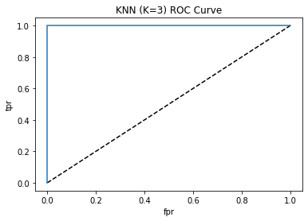

```python
fpr, tpr, thresholds = roc_curve(y_test, y_pred_proba)
plt.plot([0,1],[0,1], 'k--')
plt.plot(fpr, tpr, label='KNN')
plt.xlabel('fpr')
plt.ylabel('tpr')
plt.title('KNN (K=3) ROC Curve')
plt.show()
```

```python
roc_auc_score(y_test, y_pred_proba)
```

```
1.0
```

```python
prediction_df = pd.DataFrame(pd.read_csv('data/Table2/table2_predict.csv')).drop('Output', axis=1)

predict_11 = knn.predict(prediction_df[0:1])
predict_12 = knn.predict(prediction_df[1:2])
```

```python
if predict_11 == 1:
    print('Sample 11: Yes')
else:
    print('Sample 11: No')
```

```
Sample 11: No
```

```python
if predict_12 == 1:
    print('Sample 12: Yes')
else:
    print('Sample 12: No')
```

```
Sample 12: Yes
```

**4. Decision Tree (20 Points + 10 Points)**

**4.1** Consider the hypothesis space defined over these instances (Table 3), in which each hypothesis is represented by a pair of 5-tuples. Please provide a hand trace of the ID3 algorithm to build a Decision Tree Classifier.

Table 3: Training examples for the target concept PlayTennis

| D | Outlook | Temperature | Humidity | Wind | Play |
| --- | --- | --- | --- | --- | --- |
| D1 | Sunny | Hot | High | Weak | No |
| D2 | Sunny | Hot | High | Strong | Yes |
| D3 | Rain | Hot | High | Weak | Yes |
| D4 | Rain | Mild | Normal | Strong | No |
| D5 | Rain | Cool | High | Weak | No |
| D6 | Rain | Mild | Normal | Strong | No |
| D7 | Overcast | Cool | Normal | Strong | Yes |
| D8 | Sunny | Cool | High | Weak | No |
| D9 | Sunny | Cool | High | Strong | Yes |
| D10 | Rain | Mild | High | Strong | Yes |

**Entropy (One Attribute) [$E(S)$]**

$E(S) = \sum_{i=1}^c - \,p_i log_2 p_i$

**Entropy (Multi Attributes) [$E(T,X)$]**

$E(T,X) = \sum_{c \in X} P(c) E(c) = P(X_1) \cdot c_1 log_2 c_1 + P(X_2) \cdot c_2 log_2 c_2 + ... + P(X_n) \cdot c_n log_2 c_n$

**Information Gain [$G(T,X)$]**

$G(T,X) = E(T) - E(T,X)$

**Best Split Point [$SplitInfo_A(D)$]**

$SplitInfo_A(D) = \sum_{j=1}^v \frac{|D_j|}{|D|} \cdot log_2 (\frac{|D_j|}{|D|})$

**Gain Ratio [$GainRatio(A)$]**

$GainRatio(A) = \frac{Gain(A)}{SplitInfo(A)}$

**ID3 Algorithm**

**Play, Outlook**

$E(Play, Outlook) = P(Outlook) \cdot E(Outlook_{i_{p,\neg p}})$

$ = P(Sunny) \cdot E(Sunny_p, Sunny_{\neg p}) + P(Overcast) \cdot E(Overcast_p, Overcast_{\neg p}) + P(Rain) \cdot E(Rain_p, Rain_{\neg p})$

**Play, Temperature**

$E(Play, Temperature) = P(Temperature) \cdot E(Temperature_{i_{p,\neg p}})$

$ = P(Hot) \cdot E(Hot_p, Hot_{\neg p}) + P(Mild) \cdot E(Mild_p, Mild_{\neg p}) + P(Cool) \cdot E(Cool_p, Cool_{\neg p})$

$ = (0.3)(0.918) + (0.3)(0.918) + (.4)(1) = 0.9508$

$G(Play,Temperature) = E(Play) - E(Play, Temperature) = E(5,5) - 0.9508 = 1 - 0.9508 = 0.0492 \approx 0.05$

**Play, Humidity**

$E(Play, Humidity) = P(Humidity) \cdot E(Humidity_{i_{p,\neg p}})$

$ = P(High) \cdot E(High_p, High_{\neg p}) + P(Normal) \cdot E(Normal_p, Normal_{\neg p})$

$ = (0.7)(0.985) + (0.3)(0.918) = 0.9649$

$G(Play,Humidity) = E(Play) - E(Play, Humidity) = E(5,5) - 0.9649 = 1 - 0.9649 = 0.0351 \approx 0.04 $

**Play, Wind**

$E(Play, Wind) = P(Wind) \cdot E(Wind_{i_{p,\neg p}})$

$ = P(Strong) \cdot E(Strong_p, Strong_{\neg p}) + P(Weak) \cdot E(Weak_p, Weak_{\neg p})$

$ = (0.6)(0.918) + (0.4)(1.811) = 0.8752$

$G(Play,Wind) = E(Play) - E(Play, Wind) = E(5,5) - 0.8752 = 1 - 0.8752 = 0.1248 \approx 0.13$

$G(Play,Wind) = 0.13$

$\implies largest \,InfoGain = 0.13$

$\therefore root node = Wind$

**Wind = Weak**

| Outlook | Temperature | Humidity | Play |
| --- | --- | --- | --- |
| Sunny | Cool | High | No |
| Sunny | Hot | High | No |
| Rain | Hot | High | Yes |
| Rain | Cool | High | No |

**Play, Outlook**

$E(Play, Outlook) = P(Outlook) \cdot E(Outlook_{i_{p,\neg p}})$

$ = P(Sunny) \cdot E(Sunny_p, Sunny_{\neg p}) + P(Rain) \cdot E(Rain_p, Rain_{\neg p})$

$ = (0.5)(0) + (0.5)(1) = 0.5$

$G(Play,Outlook) = E(Play) - E(Play,Outlook) = E(1,3) - 0.5 = 0.811 - 0.5 = 0.311 \approx 0.3$

**Play, Temperature**

$E(Play, Temperature) = P(Temperature) \cdot E(Temperature_{i_{p,\neg p}})$

$ = P(Hot) \cdot E(Hot_p, Hot_{\neg p}) + P(Mild) \cdot E(Mild_p, Mild_{\neg p}) + P(Cool) \cdot E(Cool_p, Cool_{\neg p})$

$ = (0.5)(0) + (0.5)(1) = 0.5$

$G(Play,Temperature) = E(Play) - E(Play, Temperature) = E(1,3) - 0.5 = 0.811 - 0.5 = 0.311 \approx 0.3$

**Play, Humidity**

$E(Play, Humidity) = P(Humidity) \cdot E(Humidity_{i_{p,\neg p}})$

$ = P(High) \cdot E(High_p, High_{\neg p})$

$ = (1)(0.811) = 0.811$

$G(Play,Humidity) = E(Play) - E(Play, Humidity) = E(1,3) - 0.811 = 0.811 - 0.811 = 0$

$G(Play,Outlook) \, and \, G(Play,Temperature) = 0.3$

$\implies largest \,InfoGain = 0.3$

$\therefore next \, nodes = Outlook \, and \,Temperature$

**Wind = Weak $\implies$ Outlook = Sunny**

| Outlook | Temperature | Humidity | Play |
| --- | --- | --- | --- |
| Sunny | Cool | High | No |
| Sunny | Hot | High | No |

**$Sunny \implies Play=No$**

**Wind = Weak $\implies$ Outlook = Rain**

| Outlook | Temperature | Humidity | Play |
| --- | --- | --- | --- |
| Rain | Hot | High | Yes |
| Rain | Cool | High | No |

**$Rain \implies Hot \implies Play=Yes$**

**$Rain \implies Cool \implies Play=No$**

**Wind = Strong**

| Outlook | Temperature | Humidity | Play |
| --- | --- | --- | --- |
| Sunny | Hot | High | Yes |
| Sunny | Cool | High | Yes |
| Rain | Mild | High | Yes |
| Rain | Mild | Normal | No |
| Rain | Mild | Normal | No |
| Overcast | Cool | Normal | Yes |

**Play, Outlook**

$E(Play, Outlook) = P(Outlook) \cdot E(Outlook_{i_{p,\neg p}})$

$ = P(Sunny) \cdot E(Sunny_p, Sunny_{\neg p}) + P(Overcast) \cdot E(Overcast_p, Overcast_{\neg p}) + P(Rain) \cdot E(Rain_p, Rain_{\neg p})$

$ = (0.333)(0) + (0.167)(0) + (.5)(0.918) = 0.459$

$G(Play,Outlook) = E(Play) - E(Play,Outlook) = E(4,2) - 0.459 = 0.918 - 0.459 = 0.459 \approx 0.45$

**Play, Temperature**

$E(Play, Temperature) = P(Temperature) \cdot E(Temperature_{i_{p,\neg p}})$

$ = P(Hot) \cdot E(Hot_p, Hot_{\neg p}) + P(Mild) \cdot E(Mild_p, Mild_{\neg p}) + P(Cool) \cdot E(Cool_p, Cool_{\neg p})$

$ = (0.333)(0) + (0.5)(0.918) + (0.167)(0) = 0.459$

$G(Play,Temperature) = E(Play) - E(Play, Temperature) = E(4,2) - 0.459 = 0.918 - 0.459 = 0.459 \approx 0.45$

**Play, Humidity**

$E(Play, Humidity) = P(Humidity) \cdot E(Humidity_{i_{p,\neg p}})$

$ = P(High) \cdot E(High_p, High_{\neg p}) + P(Normal) \cdot E(Normal_p, Normal_{\neg p})$

$ = (0.5)(0) + (0.5)(0.918) = 0.459$

$G(Play,Humidity) = E(Play) - E(Play, Humidity) = E(4,2) - 0.459 = 0.918 - 0.459 = 0.459 \approx 0.45$

$\implies next \, node \, arbitrary$

$Outlook \, used \, at \, tree \, level \, 1$

$Temperature \, used \, at \, tree \, level \, 2$

$\therefore next \, nodes = Humidity \implies Outlook$

**Wind = Strong $\implies$ Humidity = Normal**

| Humidity | Outlook | Temperature | Play |
| --- | --- | --- | --- |
| Normal | Rain | Mild | No |
| Normal | Rain | Mild | No |
| Normal | Overcast | Cool | Yes |

**$Normal \implies Rain \implies No$**

**$Normal \implies Overcast \implies Yes$**

**Wind = Strong $\implies$ Humidity = High**

| Humidity | Outlook | Temperature | Play |
| --- | --- | --- | --- |
| High | Sunny | Hot | Yes |
| High | Sunny | Cool | Yes |
| High | Rain | Mild | Yes |

**$High \implies Yes$**

**Decision Tree - Play or Not Play**

[figure not shown]

**4.2** Consider the following example and calculate the accuracy of the classifier with precision, recall, F1-score, sensitivity, specificity and ROC curve using Python.

```python
from sklearn.tree import DecisionTreeClassifier
from sklearn.preprocessing import LabelEncoder
from sklearn.tree import export_graphviz
from sklearn.externals.six import StringIO
from IPython.display import Image
import pydotplus
```

```python
play_df = pd.DataFrame(pd.read_csv('data/Table3/table3.csv'))
play_df = play_df.drop('D', axis=1)
```

```python
play_df.head()
```

|  | Outlook | Temperature | Humidity | Wind | Play |
| --- | --- | --- | --- | --- | --- |
| 0 | Sunny | Hot | High | Weak | No |
| 1 | Sunny | Hot | High | Strong | Yes |
| 2 | Rain | Hot | High | Weak | Yes |
| 3 | Rain | Mild | Normal | Strong | No |
| 4 | Rain | Cool | High | Weak | No |

```python
play_df['Play_Label'] = play_df['Play'].apply(make_label)
play_df.head()
```

|  | Outlook | Temperature | Humidity | Wind | Play | Play_Label |
| --- | --- | --- | --- | --- | --- | --- |
| 0 | Sunny | Hot | High | Weak | No | 0 |
| 1 | Sunny | Hot | High | Strong | Yes | 1 |
| 2 | Rain | Hot | High | Weak | Yes | 1 |
| 3 | Rain | Mild | Normal | Strong | No | 0 |
| 4 | Rain | Cool | High | Weak | No | 0 |

```python
le = LabelEncoder()
play_df['Outlook_Label'] = le.fit_transform(play_df.Outlook)
play_df['Temperature_Label'] = le.fit_transform(play_df.Temperature)
play_df['Humidity_Label'] = le.fit_transform(play_df.Humidity)
play_df['Wind_Label'] = le.fit_transform(play_df.Wind)
play_df.head(10)
```

|  | Outlook | Temperature | Humidity | Wind | Play | Play_Label | Outlook_Label | Temperature_Label | Humidity_Label | Wind_Label |
| --- | --- | --- | --- | --- | --- | --- | --- | --- | --- | --- |
| 0 | Sunny | Hot | High | Weak | No | 0 | 2 | 1 | 0 | 1 |
| 1 | Sunny | Hot | High | Strong | Yes | 1 | 2 | 1 | 0 | 0 |
| 2 | Rain | Hot | High | Weak | Yes | 1 | 1 | 1 | 0 | 1 |
| 3 | Rain | Mild | Normal | Strong | No | 0 | 1 | 2 | 1 | 0 |
| 4 | Rain | Cool | High | Weak | No | 0 | 1 | 0 | 0 | 1 |
| 5 | Rain | Mild | Normal | Strong | No | 0 | 1 | 2 | 1 | 0 |
| 6 | Overcast | Cool | Normal | Strong | Yes | 1 | 0 | 0 | 1 | 0 |
| 7 | Sunny | Cool | High | Weak | No | 0 | 2 | 0 | 0 | 1 |
| 8 | Sunny | Cool | High | Strong | Yes | 1 | 2 | 0 | 0 | 0 |
| 9 | Rain | Mild | High | Strong | Yes | 1 | 1 | 2 | 0 | 0 |

```python
en_play_df = play_df[['Outlook_Label', 'Temperature_Label', 'Humidity_Label', 'Wind_Label', 'Play_Label']]
en_play_df.head(10)
```

|  | Outlook_Label | Temperature_Label | Humidity_Label | Wind_Label | Play_Label |
| --- | --- | --- | --- | --- | --- |
| 0 | 2 | 1 | 0 | 1 | 0 |
| 1 | 2 | 1 | 0 | 0 | 1 |
| 2 | 1 | 1 | 0 | 1 | 1 |
| 3 | 1 | 2 | 1 | 0 | 0 |
| 4 | 1 | 0 | 0 | 1 | 0 |
| 5 | 1 | 2 | 1 | 0 | 0 |
| 6 | 0 | 0 | 1 | 0 | 1 |
| 7 | 2 | 0 | 0 | 1 | 0 |
| 8 | 2 | 0 | 0 | 0 | 1 |
| 9 | 1 | 2 | 0 | 0 | 1 |

```python
X = en_play_df.drop('Play_Label', axis=1)
y = en_play_df['Play_Label'].values
```

# Decision Tree

## Train_Test_Split = 67/33 Train/Test

```python
X_train, X_test, y_train, y_test = train_test_split(X, y, test_size=0.33, random_state=0)
dtc = DecisionTreeClassifier()
dtc = dtc.fit(X_train, y_train)

print('Train Accuracy Score:', dtc.score(X_train, y_train))
print('Test Accuracy Score:', dtc.score(X_test, y_test))
```

```
Train Accuracy Score: 1.0
Test Accuracy Score: 0.75
```

```python
y_pred = dtc.predict(X_test)
```

```python
confusion_matrix(y_test, y_pred)
```

```
array([[1, 0],
       [1, 2]])
```

```python
pd.crosstab(y_test, y_pred, rownames=['Real'], colnames=['Predicted'], margins=True)
```

| Predicted Real | 0 | 1 | All |
| --- | --- | --- | --- |
| 0 | 1 | 0 | 1 |
| 1 | 1 | 2 | 3 |
| All | 2 | 2 | 4 |

```python
print(classification_report(y_test, y_pred))
```

```
              precision    recall  f1-score   support

           0       0.50      1.00      0.67         1
           1       1.00      0.67      0.80         3

   micro avg       0.75      0.75      0.75         4
   macro avg       0.75      0.83      0.73         4
weighted avg       0.88      0.75      0.77         4
```

```python
y_pred_proba = dtc.predict_proba(X_test)[:,1]
```

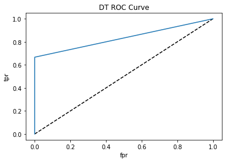

```python
fpr, tpr, thresholds = roc_curve(y_test, y_pred_proba)
plt.plot([0,1],[0,1], 'k--')
plt.plot(fpr, tpr, label='KNN')
plt.xlabel('fpr')
plt.ylabel('tpr')
plt.title('DT ROC Curve')
plt.show()
```

```python
roc_auc_score(y_test, y_pred_proba)
```

```
0.8333333333333333
```

```python
features = ['Outlook', 'Temperature', 'Humidity', 'Wind']
dot_data = StringIO()
export_graphviz(dtc, out_file=dot_data, filled=True, rounded=True, special_characters=True, feature_names=features, class_names=['No','Yes'])
```

[figure not shown]

```python
graph = pydotplus.graph_from_dot_data(dot_data.getvalue())
graph.write_png('dt_images/play_67-33.png')
Image(graph.create_png())
```

## Optimze DT

### Entropy, max_depth=3

```python
dtc = DecisionTreeClassifier(criterion='entropy', max_depth=3)
dtc = dtc.fit(X_train, y_train)
print('Train Accuracy Score:', dtc.score(X_train, y_train))
print('Test Accuracy Score:', dtc.score(X_test, y_test))
```

```
Train Accuracy Score: 1.0
Test Accuracy Score: 0.75
```

```python
y_pred = dtc.predict(X_test)
confusion_matrix(y_test, y_pred)
```

```
array([[1, 0],
       [1, 2]])
```

```python
pd.crosstab(y_test, y_pred, rownames=['Real'], colnames=['Predicted'], margins=True)
```

| Predicted Real | 0 | 1 | All |
| --- | --- | --- | --- |
| 0 | 1 | 0 | 1 |
| 1 | 1 | 2 | 3 |
| All | 2 | 2 | 4 |

```python
y_pred_proba = dtc.predict_proba(X_test)[:,1]
```

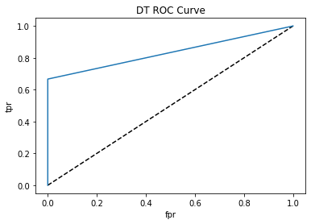

```python
fpr, tpr, thresholds = roc_curve(y_test, y_pred_proba)
plt.plot([0,1],[0,1], 'k--')
plt.plot(fpr, tpr, label='KNN')
plt.xlabel('fpr')
plt.ylabel('tpr')
plt.title('DT ROC Curve')
plt.show()
```

```python
roc_auc_score(y_test, y_pred_proba)
```

```
0.8333333333333333
```

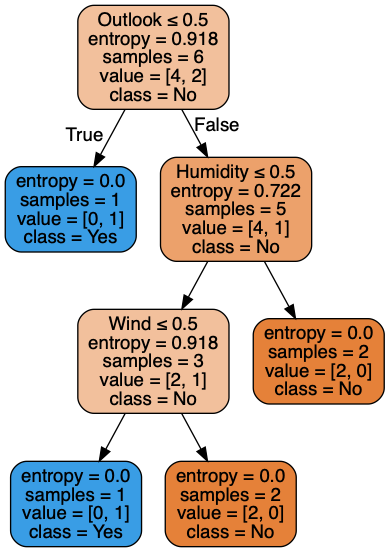

```python
features = ['Outlook', 'Temperature', 'Humidity', 'Wind']
dot_data = StringIO()
export_graphviz(dtc, out_file=dot_data, filled=True, rounded=True, special_characters=True, feature_names=features, class_names=['No','Yes'])
graph = pydotplus.graph_from_dot_data(dot_data.getvalue())
graph.write_png('dt_images/treeIV_67-33.png')
Image(graph.create_png())
```